# Module 05: Latent Class and Latent Profile Analysis

Computational Social Science — Graduate & Undergraduate

2026-04-04

# 1 Overview: When Distributions Are the Wrong Frame

Standard quantitative analysis is **variable-centred**: it asks how variables relate to each other across a population. Education predicts income; social trust predicts civic participation; conservative ideology predicts political disengagement. The assumption is that these relationships hold, in roughly the same way, for everyone.

**Person-centred analysis** challenges this assumption. It asks: are there qualitatively distinct *types* of people for whom these relationships look fundamentally different? Rather than finding the average relationship between political identity and media consumption across all respondents, it asks whether there are discrete types — political identity profiles — each with their own characteristic media behaviour.

This distinction matters. Average relationships can mask deep heterogeneity. The average correlation between social media use and depression may be near zero even if there is a small group for whom the relationship is very strong, and a larger group for whom it is slightly positive, and a larger group still for whom it is essentially absent. A typological analysis finds those groups; a variable-centred analysis averages over them.

**Learning goals:**

- Explain the conceptual difference between variable-centred and person-centred analysis
- Run a complete LCA workflow: data preparation, model fitting, selection, interpretation
- Read the full poLCA output section by section
- Assess class quality using posterior probabilities, entropy, and classification certainty
- Interpret class profiles and name classes substantively
- Run LPA on continuous indicators using tidyLPA
- Connect class membership to external predictors and outcomes

# 2 Part A: Latent Class Analysis

## 2.1 The Conceptual Model

LCA assumes the population consists of $K$ mutually exclusive, exhaustive latent classes. Within each class, the observed items are **locally independent** — uncorrelated with each other. All item correlations in the full sample arise because different classes respond differently to different items.

For a binary item $Y_j$ and class $k$:
$$P(Y_j = 1 \mid \text{Class} = k) =
\rho_{jk}$$

The $\rho_{jk}$ values are the **item response probabilities** — the probability that a member of class $k$ gives a “Yes” response to item $j$. These are the core output you interpret to understand what each class means.

**What a latent class is not:** It is not a group defined by a threshold on a single variable. It is defined by a *pattern* across multiple variables simultaneously. A person belongs to a class because their overall response pattern matches the class’s characteristic profile, not because they scored high or low on one item.

## 2.2 The cheating Dataset

We use `cheating` from `poLCA`: 319 undergraduates responding to four binary questions about academic dishonesty.

```r
data("cheating")

cat("=== cheating Dataset ===\n")
```

```
## === cheating Dataset ===
```

```r
cat("N:", nrow(cheating), "respondents\n\n")
```

```
## N: 319 respondents
```

```r
cat("Items (1=No, 2=Yes in poLCA coding):\n")
```

```
## Items (1=No, 2=Yes in poLCA coding):
```

```r
tibble(
  Item = c("LIEEXAM","LIEPAPER","FRAUD","COPYEXAM"),
  Question = c(
    "Told instructor missed exam for false reason",
    "Told instructor missed paper deadline falsely",
    "Turned in work done by someone else",
    "Copied from another student during exam"
  )
) |>
  kbl() |>
  kable_styling(bootstrap_options=c("striped","hover"), full_width=FALSE)
```

| Item | Question |
| --- | --- |
| LIEEXAM | Told instructor missed exam for false reason |
| LIEPAPER | Told instructor missed paper deadline falsely |
| FRAUD | Turned in work done by someone else |
| COPYEXAM | Copied from another student during exam |

```r
cat("\nMarginal frequencies (% responding Yes = category 2):\n")
```

```
##
## Marginal frequencies (% responding Yes = category 2):
```

```r
cheating |>
  summarise(across(c(LIEEXAM,LIEPAPER,FRAUD,COPYEXAM),
                   ~round(mean(.x==2)*100,1))) |>
  pivot_longer(everything(), names_to="Item", values_to="Pct_Yes") |>
  kbl(col.names=c("Item","% Yes")) |>
  kable_styling(bootstrap_options=c("striped","condensed"), full_width=FALSE)
```

| Item | % Yes |
| --- | --- |
| LIEEXAM | 10.7 |
| LIEPAPER | 11.9 |
| FRAUD | 6.6 |
| COPYEXAM | 21.3 |

**Why these marginal rates matter:** Before running LCA, understand what the data looks like on each item separately. Items with very low (< 5%) or very high (> 95%) marginal rates carry little information for class separation — almost everyone gives the same response, so the item cannot differentiate classes. Items in the 20–80% range are most informative.

## 2.3 Fitting Multiple Models

poLCA requires items coded as integers starting at 1. For binary items: 1 = No, 2 = Yes.

**CRITICAL: Always use `nrep` (multiple random starts).** LCA optimisation can converge to local maxima — incorrect solutions that look right but are not the global optimum. Run the model from many random starting values and keep the solution with the highest log-likelihood.

```r
set.seed(2024)

# Define the formula: all four items on the right, 1 on the left (no covariates yet)
f_cheat <- cbind(LIEEXAM, LIEPAPER, FRAUD, COPYEXAM) ~ 1

# Fit K=1 to K=4 models
fit_all <- map_dfr(1:4, function(k) {
  # nrep=10: fit from 10 random starts, keep best solution
  fits <- map(1:10, ~poLCA(f_cheat, cheating, nclass=k,
                            maxiter=2000, verbose=FALSE))
  # Keep the run with the highest log-likelihood (best solution)
  best  <- fits[[which.max(sapply(fits, `[[`, "llik"))]]

  # Compute entropy: measure of classification certainty (0=uncertain, 1=certain)
  pp    <- best$posterior
  # Entropy formula: 1 - (average cross-entropy / log K)
  ent   <- if (k == 1) NA_real_ else {
    1 - (-sum(pp * log(pp + 1e-10)) / (nrow(pp) * log(ncol(pp))))
  }

  tibble(
    K       = k,
    LogLik  = round(best$llik, 2),
    AIC     = round(best$aic, 2),
    BIC     = round(best$bic, 2),
    Npar    = best$npar,
    Entropy = round(ent, 3),
    Min_class_pct = if (k==1) 100 else round(min(best$P)*100, 1)
  )
})

kbl(fit_all,
    caption = "LCA Model Fit: K = 1–4 Classes (cheating dataset)",
    col.names = c("K","Log-Lik","AIC","BIC","# Params","Entropy","Min class %")) |>
  kable_styling(bootstrap_options=c("striped","hover")) |>
  row_spec(which.min(fit_all$BIC), bold=TRUE, background="#EAFAF1") |>
  footnote(general=paste(
    "Bold/green row = BIC-preferred solution.",
    "\nEntropy: 0 = classes perfectly overlap (useless), 1 = perfect separation.",
    "\nEntropy > .80 is generally considered good classification certainty.",
    "\nMin class % = size of the smallest class. Classes < 5% may be noise."
  ))
```

LCA Model Fit: K = 1–4 Classes (cheating dataset)

| K | Log-Lik | AIC | BIC | # Params | Entropy | Min class % |
| --- | --- | --- | --- | --- | --- | --- |
| 1 | -467.44 | 942.88 | 957.94 | 4 | NA | 100.0 |
| 2 | -440.03 | 898.05 | 931.94 | 9 | 0.737 | 16.1 |
| 3 | -436.24 | 900.47 | 953.18 | 14 | 0.840 | 3.5 |
| 4 | -436.15 | 910.29 | 981.83 | 19 | 0.566 | 5.5 |

Note:  
Bold/green row = BIC-preferred solution. Entropy: 0 = classes perfectly overlap (useless), 1 = perfect separation. Entropy > .80 is generally considered good classification certainty. Min class % = size of the smallest class. Classes < 5% may be noise.

## 2.4 Reading the Model Selection Table

How to Read the Model Selection Table

| Criterion | Direction | What It Measures |
| --- | --- | --- |
| Log-Likelihood | Higher = better | Overall model fit. Increases with every additional class — always check against BIC to see if the improvement justifies the complexity. |
| AIC | Lower = better | AIC penalises for number of parameters. Tends to favour more classes than BIC. Use as secondary criterion. |
| BIC | Lower = better | BIC penalises more heavily for parameters. Preferred criterion in social science for class enumeration. Find the ‘elbow’ or minimum. |
| Entropy | Higher = better (> .80 good) | Classification certainty: how unambiguously each respondent is assigned to a class. Does not indicate ‘correct’ K — use alongside BIC. |
| Min class % | Should be > 5% | Smallest class as % of sample. Very small classes (< 5%) may be noise or artefacts. Verify they are theoretically interpretable. |

## 2.5 Running and Reading the Best Model

```r
best_k <- fit_all$K[which.min(fit_all$BIC)]
cat("BIC-optimal K:", best_k, "\n\n")
```

```
## BIC-optimal K: 2
```

```r
set.seed(42)
lca <- poLCA(f_cheat, cheating, nclass=best_k,
             maxiter=2000, verbose=TRUE, nrep=10, graphs=FALSE)
```

```
## Model 1: llik = -440.0271 ... best llik = -440.0271
## Model 2: llik = -440.0271 ... best llik = -440.0271
## Model 3: llik = -440.0271 ... best llik = -440.0271
## Model 4: llik = -440.0271 ... best llik = -440.0271
## Model 5: llik = -440.0271 ... best llik = -440.0271
## Model 6: llik = -440.0271 ... best llik = -440.0271
## Model 7: llik = -440.0271 ... best llik = -440.0271
## Model 8: llik = -440.0271 ... best llik = -440.0271
## Model 9: llik = -440.0271 ... best llik = -440.0271
## Model 10: llik = -440.0271 ... best llik = -440.0271
## Conditional item response (column) probabilities,
##  by outcome variable, for each class (row)
##
## $LIEEXAM
##            Pr(1)  Pr(2)
## class 1:  0.9834 0.0166
## class 2:  0.4231 0.5769
##
## $LIEPAPER
##            Pr(1)  Pr(2)
## class 1:  0.9708 0.0292
## class 2:  0.4109 0.5891
##
## $FRAUD
##            Pr(1)  Pr(2)
## class 1:  0.9629 0.0371
## class 2:  0.7839 0.2161
##
## $COPYEXAM
##            Pr(1)  Pr(2)
## class 1:  0.8180 0.1820
## class 2:  0.6236 0.3764
##
## Estimated class population shares
##  0.8394 0.1606
##
## Predicted class memberships (by modal posterior prob.)
##  0.8307 0.1693
##
## =========================================================
## Fit for 2 latent classes:
## =========================================================
## number of observations: 319
## number of estimated parameters: 9
## residual degrees of freedom: 6
## maximum log-likelihood: -440.0271
##
## AIC(2): 898.0542
## BIC(2): 931.9409
## G^2(2): 7.764242 (Likelihood ratio/deviance statistic)
## X^2(2): 8.323451 (Chi-square goodness of fit)
##
```

**Reading the verbose poLCA output during estimation:**

```r
# Print the full model object
print(lca)
```

```
## Conditional item response (column) probabilities,
##  by outcome variable, for each class (row)
##
## $LIEEXAM
##            Pr(1)  Pr(2)
## class 1:  0.9834 0.0166
## class 2:  0.4231 0.5769
##
## $LIEPAPER
##            Pr(1)  Pr(2)
## class 1:  0.9708 0.0292
## class 2:  0.4109 0.5891
##
## $FRAUD
##            Pr(1)  Pr(2)
## class 1:  0.9629 0.0371
## class 2:  0.7839 0.2161
##
## $COPYEXAM
##            Pr(1)  Pr(2)
## class 1:  0.8180 0.1820
## class 2:  0.6236 0.3764
##
## Estimated class population shares
##  0.8394 0.1606
##
## Predicted class memberships (by modal posterior prob.)
##  0.8307 0.1693
##
## =========================================================
## Fit for 2 latent classes:
## =========================================================
## number of observations: 319
## number of estimated parameters: 9
## residual degrees of freedom: 6
## maximum log-likelihood: -440.0271
##
## AIC(2): 898.0542
## BIC(2): 931.9409
## G^2(2): 7.764242 (Likelihood ratio/deviance statistic)
## X^2(2): 8.323451 (Chi-square goodness of fit)
##
```

## 2.6 Reading the Full poLCA Output — Section by Section

Complete Guide to poLCA Print Output

[output not shown]

## 2.7 Extracting and Interpreting Class Profiles

```r
# Class sizes (population proportions)
cat("=== CLASS SIZES ===\n")
```

```
## === CLASS SIZES ===
```

```r
cat("These are the estimated population proportions Pi:\n\n")
```

```
## These are the estimated population proportions Pi:
```

```r
sizes <- round(lca$P * 100, 1)
for (k in seq_along(sizes)) {
  cat("  Class", k, ":", sizes[k], "% of population\n")
}
```

```
##   Class 1 : 83.9 % of population
##   Class 2 : 16.1 % of population
```

```r
cat("\n=== ITEM RESPONSE PROBABILITIES (Rho) ===\n")
```

```
##
## === ITEM RESPONSE PROBABILITIES (Rho) ===
```

```r
cat("P(Yes | Class k) for each item × class combination:\n\n")
```

```
## P(Yes | Class k) for each item × class combination:
```

```r
# Extract P(Yes) = P(category 2) for each item × class
rho_tbl <- map_dfr(seq_along(lca$probs), function(j) {
  item_name <- names(lca$probs)[j]
  probs_mat <- lca$probs[[j]]  # rows = classes, cols = categories (1=No, 2=Yes)
  tibble(
    Item  = item_name,
    Class = paste("Class", seq_len(nrow(probs_mat))),
    P_No  = round(probs_mat[, 1], 3),
    P_Yes = round(probs_mat[, 2], 3)
  )
})

rho_tbl |>
  dplyr::select(Item, Class, P_Yes) |>
  pivot_wider(names_from=Class, values_from=P_Yes) |>
  kbl(caption="Conditional Response Probabilities P(Yes | Class) — cheating LCA",
      col.names=c("Item", paste("Class", 1:best_k, paste0("(", sizes, "%)")))) |>
  kable_styling(bootstrap_options=c("striped","hover")) |>
  footnote(general=paste(
    "Each cell = probability of 'Yes' for a member of that class.",
    "Read: 'If someone is in Class 2, they have an X% chance of having lied about an exam.'",
    "\nHigher values = this class is more likely to have engaged in this behaviour."
  ))
```

Conditional Response Probabilities P(Yes | Class) — cheating LCA

| Item | Class 1 (83.9%) | Class 2 (16.1%) |
| --- | --- | --- |
| LIEEXAM | 0.017 | 0.577 |
| LIEPAPER | 0.029 | 0.589 |
| FRAUD | 0.037 | 0.216 |
| COPYEXAM | 0.182 | 0.376 |

Note:  
Each cell = probability of ‘Yes’ for a member of that class. Read: ‘If someone is in Class 2, they have an X% chance of having lied about an exam.’ Higher values = this class is more likely to have engaged in this behaviour.

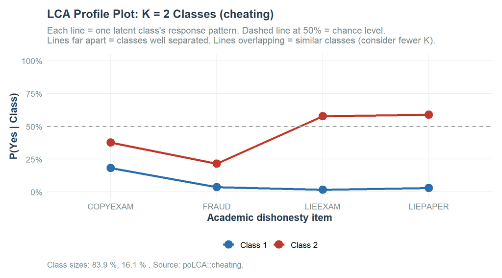

```r
ggplot(rho_tbl, aes(x=Item, y=P_Yes, colour=Class, group=Class)) +
  geom_line(linewidth=1.4) +
  geom_point(size=4.5) +
  geom_hline(yintercept=0.5, linetype="dashed", colour="grey60", linewidth=0.7) +
  scale_y_continuous(limits=c(0,1), labels=scales::percent,
                     name="P(Yes | Class)") +
  scale_colour_manual(values=css_palette(best_k), name=NULL) +
  labs(
    title    = paste0("LCA Profile Plot: K = ", best_k, " Classes (cheating)"),
    subtitle = paste(
      "Each line = one latent class's response pattern.",
      "Dashed line at 50% = chance level.",
      "\nLines far apart = classes well separated. Lines overlapping = similar classes (consider fewer K)."
    ),
    x = "Academic dishonesty item",
    caption = paste("Class sizes:", paste(sizes, "%", collapse=", "),
                    ". Source: poLCA::cheating.")
  ) +
  theme(legend.position="bottom")
```

**Naming the classes — the most important interpretive step:**

Look at each class’s profile and ask: “What kind of person is this?” The class name should reflect the *pattern* across items, not just the overall level.

- A class with high P(Yes) on all items = “Serial cheaters” (engaged in multiple forms)
- A class with low P(Yes) on all items = “Academic integrity group” (rarely cheat)
- A class with high P(Yes) on lie items but low on fraud/copying = “Excuse-givers” (lie about absences but don’t commit academic fraud)

Never use algorithmic labels like “Class 1” or “High group” in a publication. Interpretive labels like these above communicate substantive meaning.